# Pythagorean Identity

# Pythagorean Identity

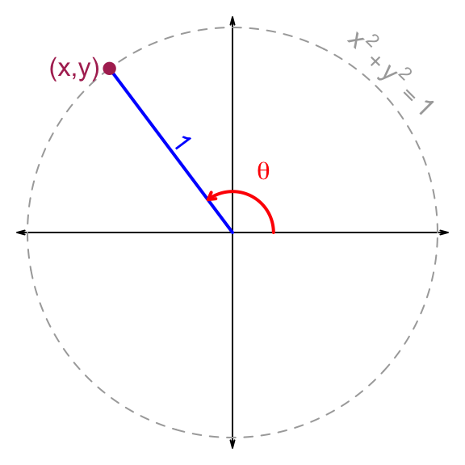

- Every point on the unit circle is a distance of $1$ unit away from the origin.
- For any point $(x,y)$ on the unit circle, $x^2+y^2=1$ (distance formula).
- We define $\sin(\theta)$ to be the $y$ coordinate on the unit circle at angle $\theta$.
- We define $\cos(\theta)$ to be the $x$ coordinate on the unit circle at angle $\theta$.
- We define $\tan(\theta)$ to be $y/x$, or the slope of the segment connecting $(0,0)$ to $(x,y)$.
- So,

$$\sin^2(\theta)+\cos^2(\theta)=1$$

- Notice, this new notation (putting an exponent between the trig function and its argument) is weird/bad but standard. To write this in a more familiar way, we could write $(\sin(\theta))^2+(\cos(\theta))^2=1$; however, you’ll almost always see the Pythagorean identity, and trig functions raised to any power, written as they are shown in $\sin^2(\theta)+\cos^2(\theta)=1$.

# Example 1

1. If $\sin(\theta)=0.644$, then what is $\cos(\theta)$?

We can use the Pythagorean identity.

$$(0.644)^2+\cos^2(\theta)=1$$

Subtract $(0.644)^2$ from both sides.

$$\cos^2(\theta)=1-(0.644)^2$$

Square root both sides.

$$|\cos(\theta)|=\sqrt{1-(0.644)^2}$$

Get a decimal approximation.

$$|\cos(\theta)|=0.7650255$$

Notice there are two possibilities: $\cos(\theta)=0.7650255$ or $\cos(\theta)=-0.7650255$. We can visualize this by drawing a unit circle and a horizontal line $y=0.644$.

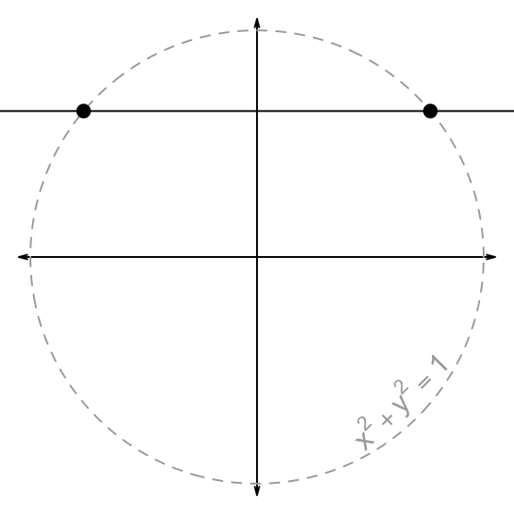

Notice, there are two points of intersection. The two points share a common $y$ coordinate, but their $x$ coordinates are opposites. The question would need to specify a quadrant for you to give a single answer!

# “But, but, woe is me. I can’t do all that algebra!”

Never fear. I’ve done the algebra and stored the results in formulae! (These can be found on the [cheat sheet](https://chadworley.github.io/a2/u13/rtt_cheat_sheet/cheat_sheet_uc_trig.pdf).)

$$\begin{align*}
\sin^2(\theta)+\cos^2(\theta)&=1 &
|\sin(\theta)|&=\sqrt{1-\cos^2(\theta)} &
|\cos(\theta)|&=\sqrt{1-\sin^2(\theta)}\\\\
\tan^2(\theta)+1&=\frac{1}{\cos^2(\theta)} &
|\tan(\theta)|&=\sqrt{\frac{1-\cos^2(\theta)}{\cos^2(\theta)}} &
|\cos(\theta)|&=\sqrt{\frac{1}{\tan^2(\theta)+1}}\\\\
\tan^2(\theta)+1&=\frac{1}{1-\sin^2(\theta)} &
|\tan(\theta)|&=\sqrt{\frac{\sin^2(\theta)}{1-\sin^2(\theta)}} &
|\sin(\theta)|&=\sqrt{\frac{\tan^2(\theta)}{\tan^2(\theta)+1}}\\\\
\end{align*}$$

# Example 2

- Given:
  - $\sin(\theta)=0.5$
  - $\theta$ is in quadrant II
- Find $\tan(\theta)$.

Find the formula that gets $\tan(\theta)$ from $\sin(\theta)$.

$$|\tan(\theta)|=\sqrt{\frac{\sin^2(\theta)}{1-\sin^2(\theta)}}$$

Substitute the given.

$$|\tan(\theta)|=\sqrt{\frac{(0.5)^2}{1-(0.5)^2}}$$

Evaluate a decimal approximation.

$$|\tan(\theta)|=0.5773503$$

In quadrant II, the slope will be **negative** for a line connecting a point on the circle to the origin. Thus,

$$\tan(\theta)=-0.5773503$$

# “That still seems difficult. Is there an easier way?”

- In Desmos, you can graph a unit circle with $x^2+y^2=1$.
- If you are given a value for $\sin(\theta)$, graph a horizontal line $y=\sin(\theta)$.
- If you are given a value for $\cos(\theta)$, graph a vertical line $x=\cos(\theta)$.
- If you are given a value for $\tan(\theta)$, graph a line $y=\tan(\theta)\cdot x$.
- If you want $\sin(\theta)$, find the $y$ coordinate of intersection in given quadrant.
- If you want $\cos(\theta)$, find the $x$ coordinate of intersection in given quadrant.
- If you want $\tan(\theta)$, find $y/x$ of intersection in given quadrant.
- Here, we can argue that because we used $x^2+y^2=1$, we are “using the Pythagorean Identity”, since $x=\cos(\theta)$ and $y=\sin(\theta)$…

# “That still seems difficult. Is there an EVEN EASIER way?”

- You can use an arctrig function to first find the angle, and then put that angle into the desired trig function.
- Unfortunately, trig functions are NOT one-to-one, so this can’t work perfectly.
- If you are given $\sin(\theta)$ and want $\tan(\theta)$, you could use $\tan(\arcsin(\sin(\theta)))$, and then fix the sign based on the quadrant.
- I will say this strategy is not really “using the Pythagorean Identity”, so it is not matching up with the learning objective.
- It is interesting that $\arcsin$ does not perfectly undo $\sin$, just like square root does not perfectly undo squaring (for example $\sqrt{(-5)^2}\ne-5$). This is because non-one-to-one functions cannot be perfectly undone.